# Deep Dive #2

## Part 1: Carbon-14 Dating

[figure not shown]

Radioactive decay is described by the exponential decay equation $N'=-rN$

Half-life is defined as $N(\tau) = \dfrac{N(0)}{2}$

(1a)

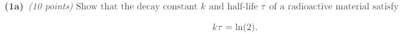

$r = k$

$$ \int \dfrac{dN}{-kN} = \int dt + c \\ \frac{-1}{k}\ln(N)=t+c \\ \ln(N)=-kt+c \\ N(t) = ce^{-kt} $$ where c encorperates $e^c$

$N(\tau)=\dfrac{N(0)}{2}=\dfrac{c}{2}$  
$N(\tau)=ce^{-k\tau}$

$$ ce^{-k\tau} = \dfrac{c}{2} e^{-k\tau} = \dfrac{1}{2} $$ inverting these we have $$ e^{k\tau} = 2$$ and taking the log of each gives us our final result $$ \ln(e^{k\tau})=\ln(2) \rightarrow k\tau=\ln(2)$$

(1b)

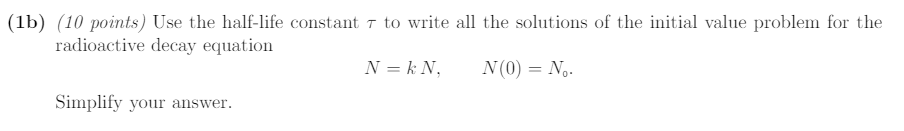

$k = \frac{\ln(2)}{\tau}$

$N(0)=N_0=ce^{-0}=c$

$$N(t)=N_0e^{-\frac{t\ln(2)}{\tau}} =N_0*2^{-\frac{t}{\tau}}= \dfrac{N_0}{2^{\frac{t}{\tau}}}$$

(2)

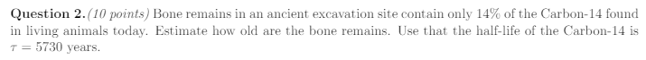

$$ \space \space .14N_0 = \dfrac{N_0}{2^\frac{t}{5730}} \\ \ln(.14)=-\frac{t}{5730}\ln(2) \space \space \\ t=-5730\frac{\ln(.14)}{\ln(2)} = 16253 \text{ years} $$

## Part 2: Newton's Cooling Law

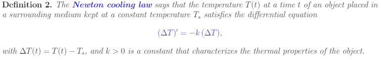

(3)

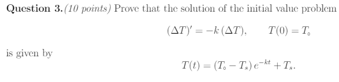

Considering the fact that the solution has no $\Delta T$'s in it, lets start there

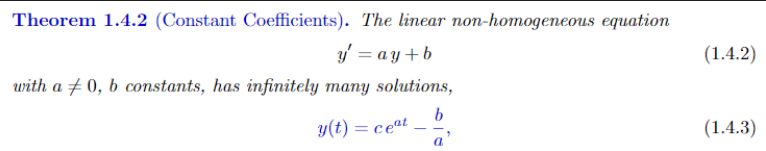

$$ T(t)=ce^{-kt}+T_s $$ Applying the initial conditions

$$ T_0=c+T_s \implies c = T_0-T_s \\ T(t)=(T_0-T_s)e^{-kt}+T_s $$

(4)

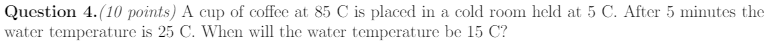

$T_0 = 85, T_s = 5, t = 5, T(t)=25$ Find $k_t$

$$ 25 = (85-5)e^{-5k}+5\\ \ln(\frac{20}{80})=\ln (e^{-5k}) \\ k = - \ln(\frac{1}{4})/5 = \ln(4)/5 $$ From this we plug in the new resultant value $T(t)=15$ to find the new time value $t$ $$ 15 = (80)2^{-\frac{2t}{5}}+5 \\ \log_2(\frac{1}{8}) = \log_2(2^{-\frac{2t}{5}}) \\ -\frac{5}{2}\log_2(\frac{1}{8})=t = 7.5 \text{ minutes} $$

## Part 3: Mixing

I think we did these in CMSE 201

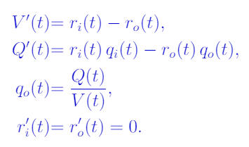

Thank you for equation #4. That means that flow rates are constant

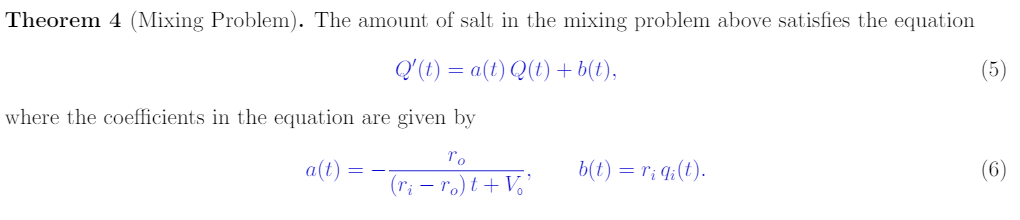

(4)

This is not hard to prove $^{1}$

Pf. We will show that $Q'(t)=r_i(t)q_i(t)-r_0(t)q_0(t) $ can be linearized. I'll refer to the equations in Definiton 3 as (1-4)

We already have $Q'(t)=b(t) - r_0(t)q_0(t)$, so we will show $-r_0(t)q_0(t) = a(t)Q(t)$

From (3) we have $$ -r_0q_0 = \dfrac{-r_0Q}{V} $$ Since (4) implies $r_i$ and $r_0$ are independent of $t$, the integral of $V'$ is simply $$V = \int V' dt = (r_i-r_0)t + c$$ We choose $c=V_0$ and insert what we've found into the above

$$ \dfrac{-r_0Q}{V} = \dfrac{-r_0}{(r_i-r_0)t+V_0}Q = a(t)Q(t) $$ Thus our proof is complete.

(6)

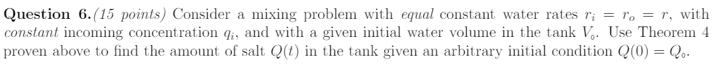

With this setup a and b is independent of t, $Q'=aQ(t)+b$

Using Theorem 1.4.2 of the book this becomes

(7)

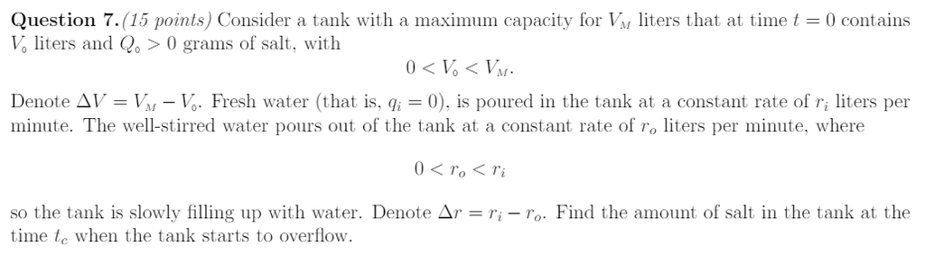

Objective: find $Q(t_c)$

1. find $t_c$. $$V(t)=(r_i-r_o)t+c$$ Since $V(t_c)=V_m$ $$V_m=(r_i-r_o)t_c+V_0$$ $$t_c=\dfrac{\Delta V }{\Delta r}$$
2. Find Q(t). Since $r_i$ does not necessarily equal $r_o$, we have to start at theorem #4

$$ a(t)=\dfrac{-r_o}{\Delta rt+V_0} \\ b(t)=r_iq_i=r_i*0=0 $$

As such, this becomes a seperable equation

$$ \dfrac{Q'}{Q(t)}=\dfrac{-r_o}{\Delta rt+V_0} \\ \int \dfrac{dQ}{Q(t)}=-r_0 \int \dfrac{dt}{\Delta rt +V_0} +c_1 \\ \ln(Q(t))= \dfrac{-r_0}{\Delta r}\ln(\Delta r t + V_0)+c_1=\ln((\Delta r t + V_0)^\dfrac{-r_0}{\Delta r})+c_1 \\ Q(t)=(\Delta rt+V_0)^{\dfrac{-r_0}{\Delta r}}*e^c=c_1(\Delta rt+V_0)^{\dfrac{-r_0}{\Delta r}} $$ Applying $Q(0)=Q_0$ we have $$Q_0 = c_1(V_0)^{\dfrac{-r_0}{\Delta r}} \\ c_1 = Q_0V_0^{\dfrac{r_0}{\Delta r}}$$

From here we encorperate $t_c$

$$ Q(t_c)=Q_0V_0^{\dfrac{r_0}{\Delta r}}(\Delta r \dfrac{\Delta V}{\Delta r}+V_0)^{\dfrac{-r_0}{\Delta r}} \\ =Q_0V_0^{\dfrac{r_0}{\Delta r}}(\Delta V+V_0)^{\dfrac{-r_0}{\Delta r}}$$ Which becomes our final equation $$ Q(t_c)=Q_0\left( \frac{V_0}{\Delta V + V_0} \right) ^\dfrac{r_0}{\Delta r} $$